# PROJECT 1- REPRODUCIBLE RESEARCH

Author: Dominik Vuksan

Mostly, we will be following the project props as they appear in order on Coursera.

So, let us get started.

Since there’s going to be data analyzing and editing, we want the tidyverse package loaded for this analyisis. Also, when we look at the variable types, we see that we need to transform the date variable to actual “date”.

```r
library(tidyverse)
data= read.csv("activity.csv")
str(data)
```

```
## 'data.frame':    17568 obs. of  3 variables:
##  $ steps   : int  NA NA NA NA NA NA NA NA NA NA ...
##  $ date    : chr  "2012-10-01" "2012-10-01" "2012-10-01" "2012-10-01" ...
##  $ interval: int  0 5 10 15 20 25 30 35 40 45 ...
```

```r
library(lubridate)
data$date= ymd(data$date)
```

After we transformed and edited our raw data, now we are heading for some cool analyses.

```r
steps.each.day= data %>% filter(!is.na(steps)) %>% group_by(date) %>% summarise(total.steps= sum(steps))
```

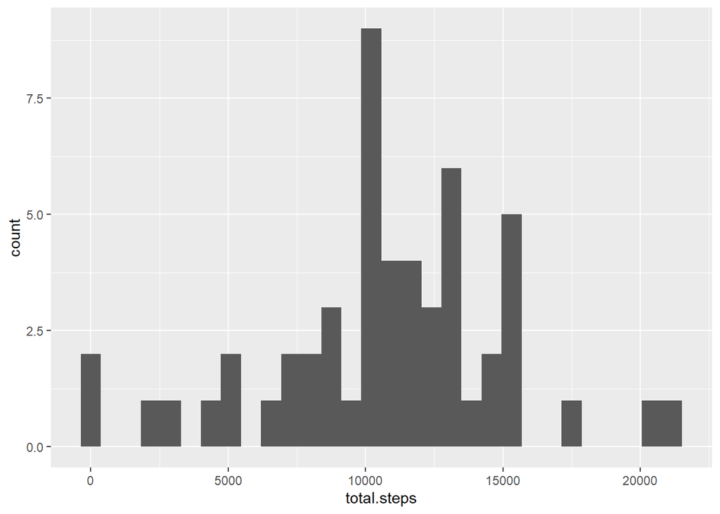

```r
ggplot(steps.each.day) + geom_histogram(aes(x= total.steps))
```

```r
mean.steps= mean(steps.each.day$total.steps)
median.steps= median(steps.each.day$total.steps)
```

Now we’re filtering data for the time series plotting.

```r
time.series= data %>% filter(!is.na(steps)) %>% group_by(interval) %>% summarise (total.steps= sum(steps))
```

The time series plot.

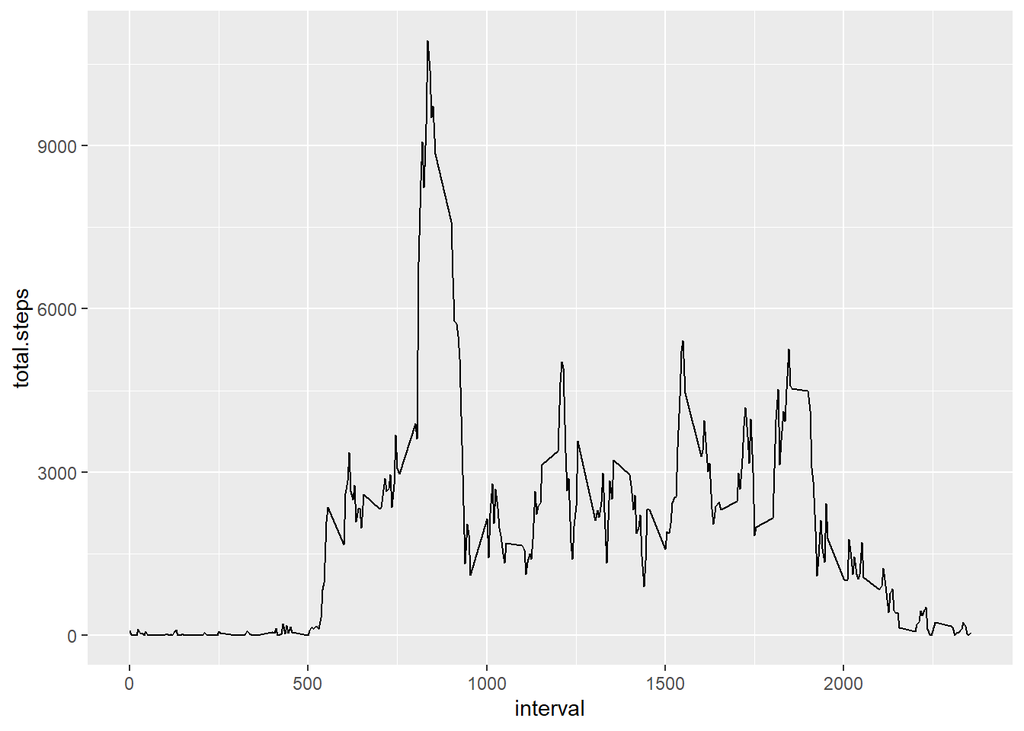

```r
ggplot(time.series) + geom_line(mapping= aes(x= interval, y= total.steps))
```

The 5-minute interval that, on average, contains the maximum number of steps.

```r
time.series[which.max(time.series$total.steps), ]
```

```
## # A tibble: 1 × 2
##   interval total.steps
##      <int>       <int>
## 1      835       10927
```

Now, we’ll see how much of NA’s is there in the dataset.

```r
sum(is.na(data))
```

```
## [1] 2304
```

Now we’ll be removing the NA values in the “steps” variable in the dataset of ours.

```r
data$steps= ifelse(is.na(data$steps), mean.steps, data$steps)
```

Creating a new dataset with mean steps instead of NA

```r
data1= data
```

```r
data$steps= ifelse(mean.steps, NA, data$steps)
```

Getting a day in the week for each date.

```r
data1$date= weekdays(data1$date)
data$date= weekdays(data$date)
```

Adding a new column “week”. If it’s a weekday, in the column will appear “weekday”. If it’s a weekend day, in the coulmn will appear “weekend”.

```r
data1= mutate(data1, week= ifelse(data1$date== "subota" | data1$date== "nedjelja", "weekend", "weekday"))
```

Filtering the weekdays and weekend days for the plot.

```r
week.activity= data1 %>% group_by(interval, week) %>% summarise(total.steps= sum(steps))
```

Making a plot.

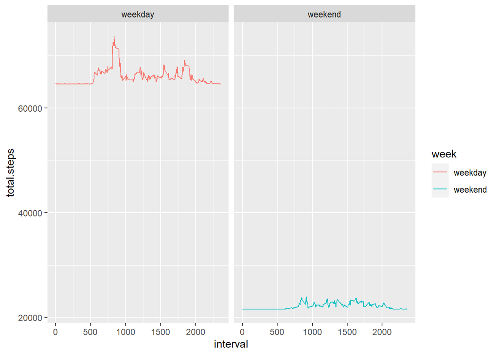

```r
ggplot(week.activity) + geom_line(mapping= aes(x= interval, y= total.steps, color= week)) + facet_wrap(~week, ncol= 2)
```